# 1_NCBI

## Master Medical Biometry/Biostatistics, Introduction to Bioinformatics, Medizinische Fakultät Heidelberg

**The purpose of these exercises is to introduce you to the NCBI, one of the most used biomedical and genomic databases.**

> Provide answers to questions that are marked with ‘Q’.

Note: in case some of the webtools are not available, we provide you with the resulting images so you can answer the questions. However try to use your results as much as you can as they can sligtly vary depending on when we generated the results.

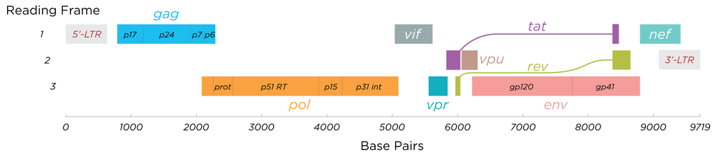

By Thomas Splettstoesser

## Biological background

HIV (Human Immunodeficiency Virus) is a lentivirus (a type of retrovirus), i.e. it has an RNA genome and replicates (copies itself) through a DNA intermediate. Its genome and proteins have been the subject of extensive research since the discovery of the virus in 1983. A complete virus particle comprises a viral envelope that encloses two copies of the single-stranded RNA genome and several enzymes.

## Information Resources: NCBI

- Go to the [NCBI](https://www.ncbi.nlm.nih.gov/) database
- Enter `HIV` in the search field and see how many hits you get in the different databases

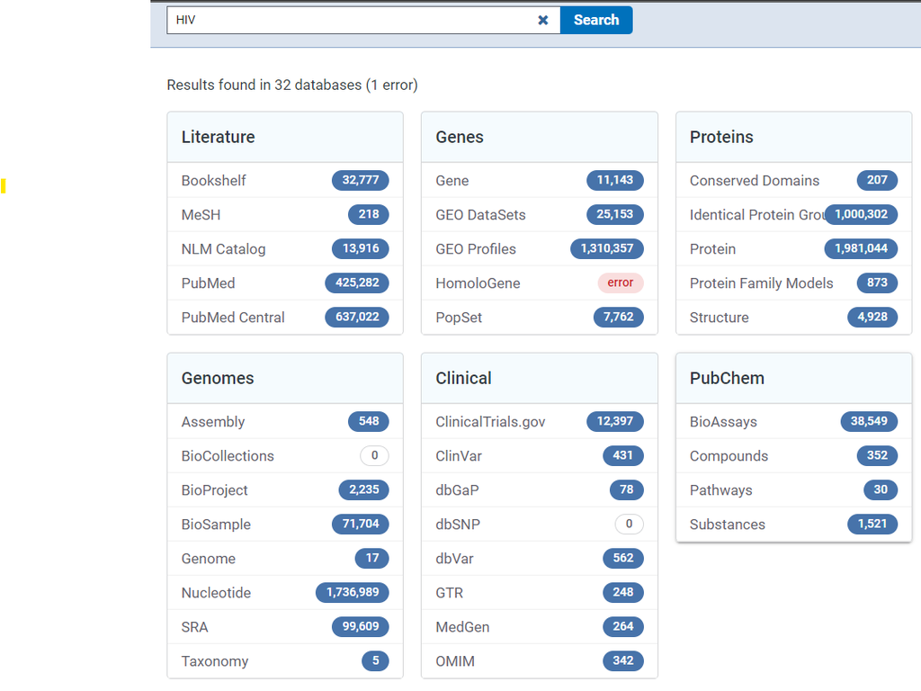

> Q1. How many HIV entries do you have in the `Gene` database?

**Click here for answer**

```
11,143 entries
this number may differ as the database is constantly
being updated.
```

- Now search for `NC_001802.1` in the search field

[figure not shown]

> Q2. Why do you get so different results?

**Click here for answer**

```
When we are using a broad query like HIV and we do not
specify where to look for it, the default is to search ALL
the fields (Gene name, text, properties, etc) so it may
be that all the results we get are not strictly HIV, but
related to, as "HIV" could be mentioned in the references,
and of course, we get results from ALL organisms, as we
didn't say "human"

When we are using the specific sequence we are sure we get
the information we are interested in. The hard part is to
know exactly which sequence we are looking for
```

- Click on the `Gene` database

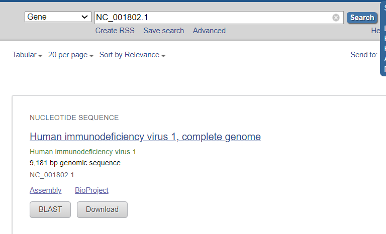

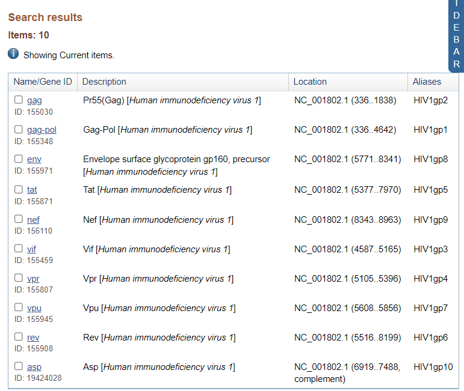

> Q3. How big is the HIV genome (how many nucleotides)? How many genes in total?

**Click here for answer**

```
9 181 bp
10 genes
```

Let’s look into the genomic structure

- Click on the `gag-pol` gene
  - Under the `Genomic context` section
    - you can see how the genes are distributed across the HIV genome
    - In dark blue we see the `gag-pol` gene

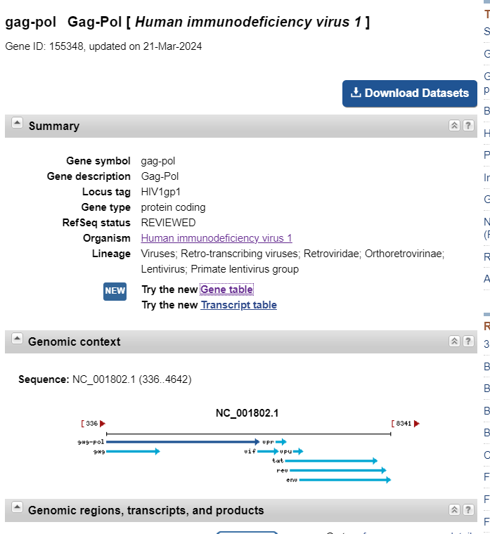

> Q4. There is a gene that overlaps with `gag-pol`, which gene is it?

**Click here for answer**

```
gag and vif
```

Under the `Genomic regions, transcripts, and products` section we have a more detailed representation of the genomic context. To simplify the view:

- In the viewer:
  - Within the `Genes` panel
    - Click on the `Settings` icon
    - Tick off `Show annotated protein features`
    - Click `Apply`

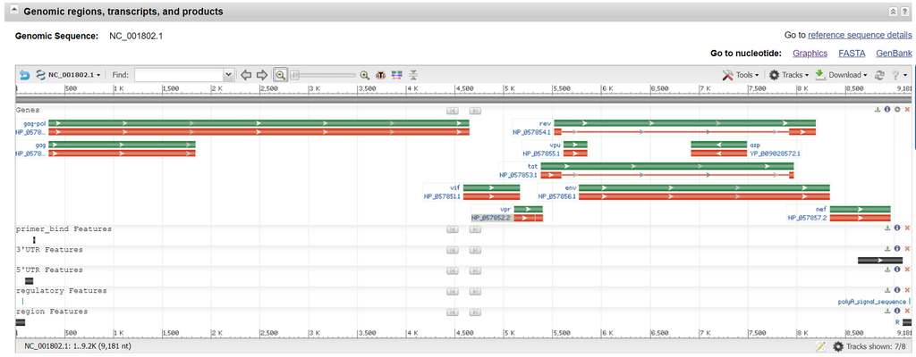

In green we have the genes, while in red we have the proteins they encode for.

- Zoom out all the way, until you see the entire genome

> Q5. Which genes have introns? How did you identify them?

**Click here for answer**

```
rev and tat

Exons are depicted with rectangular boxes while introns
with just a line. rev and tat are the only ones with both
```

Now let’s focus on the `gag-pol` protein

- In the right panel, under `Related information`, click on `Protein`
  - You will be redirected to the **Protein database**
  - You will get a list of potential hits to the `gag-pol` protein
- Click on `Gag-Pol [Human immunodeficiency virus 1] (1435 aa protein)`
  - Detailed information about the protein will be displayed

The Gag-Pol protein is composed by different regions.

> Q6. How many regions belong to the `Reverse transcriptase` function of this protein? Which are their nucleotid positions. Hint: Read under `region`

**Click here for answer**

```
There are a lot of regions that describe the different
functions of our protein:

* binding
* protease
* RNase
* transposase
* intergrases and
* the reverse transcriptase

Focusing only on the "reverse transcriptase", we can
find 3 regions:

"RT_Rtv" - 605..821
"RVT_thumb" - 828..883
"RVT_connect" - 905..1006
```

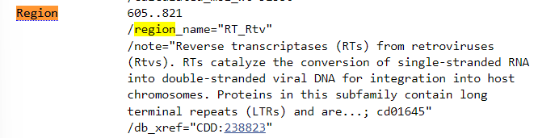

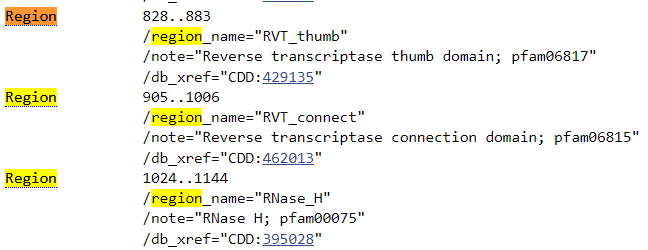

```
You will hear more about these regions in the next
practical
```

> Q7. Are there any 3D structures available for the `gag-pol` protein, how many? Hint: Look at the right panel.

**Click here for answer**

```
38 structures
The number can be different as the strucrture databases is
also in constant updating, although not as quick as with
nucleotide or aminoacid sequences
```

[figure not shown]

*Note: At the end of the practical we will see in more detail one of these structures*

Let’s visualize the functional domains that this protein has.

- In the right panel, under `Related information`, click on `CDD Search Results`
  - You will be redirected to the **Conserved Domains database**
  - You will be able to visualize the different parts of the `gag-pol` protein

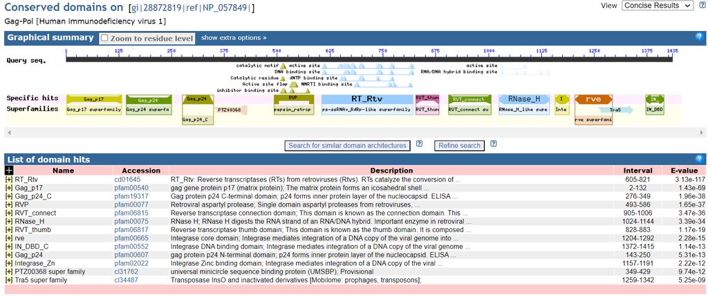

> Q8. Which domains are found within the `Reverse transcriptase` region of the protein? Hint: Make use of the their genomic positions.

**Click here for answer**

```
A domain is a region on a protein that has a specif function.

If we take the positions the ``Reverse transcriptase``
regions we looked at in the previous exercise, we should
look at positions 605-1006 (more or less)

Either you look at the table or at the illustration yuou
will see that there are 3 domains:

* RT_Rtv
* RVT_thumb
* RVT_connect

Exactly the same we identified.
```

### [Next: Sequence bioinformatics](https://github.com/marceladavila/Intro2Bioinformatics/wiki/2_Sequence_bioinformatics/)

### [Home: Intro2Bioinformatics](https://github.com/marceladavila/Intro2Bioinformatics/wiki)

Created, 2019